# Time Series Analysis

KM

# Section 1

## LEcture 3: Main Functions

1. Basic functions in R Base are:
- decompose()
- stl()
- arima()
- HolWinters()
- acf(), pacf()
- plot()
- ts()
2. Add-on package - `forecast` package

```r
# package load
library(forecast)
```

```r
library(ggplot2)
```

### Forecast structure

Function `forecast()` + standard model = Forecasting

Standar model is (1) ARIMA, (2) Sesonal decomposition, (3) Exponential smoothing, and (4) simple models (e.g., naive mean).

Forecasting Results are always in the same structure regardless of the model(which are different from function `predict()`).

In the `Forecast` library, automatic parameter selection is available both for the ARIMA model and the exponential smoothing.

### ARIMA models in Library `Forecast`

auto.arima(time_series) -> most suitable ARIMA model `auto.arima` sets the complexity with the arguments `stepwise` and `approximation`. WE can get a list of possible models, as well as the information criteria.

Arima(time_series) we could set the parameters manually (manual parameter selecion). In the manual selection, we look fro autocorrelation based on the `acf()` and `pacf()` plots. we adjust the model by `time_series` - `lags` until no more autocorrelation.

### Exponential smooothing in Library `Forecast`

Automatic function - `ets()` manual functions: `ses()`, `hw()`, `holt()`

### Plotting with Library `Forrecast`

R Base Plots: - `plot()` - `monthplot()` - `seasonplot()`

ggplot2 plots: - `autoplot()` - `ggmothplot()` - `ggseasonplot()`

### Model comparison with Library `Forecast`

`accruacy()` getting the model accuracy with a training and a test set.

`tsCV()` time series cross validation for small datasets.

### Other packages

we would use `getSymbols()`, `quantmod()` and `xts()` packages.

```r
# install.packages("quantmod")
# install.packages("xts")
```

## Lecture 4: Supporting Resources

R Time series Task View curated by Rob Hyndman (Blog on Otexts.org) https://robjhyndman.com/

Vignetts some packages come with vignettes (description, PDF)

Free e-Books “Forecasting: Principles and Practice” https://otexts.org/fpp2/index.html https://robjhyndman.com/seminars/uwa2017/

R Community on Stackoverflow.com https://stackoverflow.com/questions/tagged/r

## Lecture 5: Course Link List

Time Series Task View: https://cran.r-project.org/web/views/TimeSeries.html

Blog, Ebook and Forecast Documentation by Rob Hyndman: https://otexts.org/fpp2/intro.html

Stackoverflow Community: https://stackoverflow.com/questions

Singapur Data of Project I: https://docs.google.com/spreadsheets/d/1frieoKODnD9sX3VCZy5c3QAjBXMY-vN7k_I9gR-gcU8/pub http://www.gapminder.org/data/

German Inflation Data of Project II: https://www.statbureau.org/en/germany/inflation-tables

# Section 2: Project I Trending Data:Singapur Labor Force Participation Rate

## LEcture 6: Importing the data

Uneployment rate - Used for propaganda purposes - Easy to manipulate - Who is unemployed? - Who doesn’t show up in the metric?

Labor Force Participatin Rate - Harder to manipulate - Ratio of people in the work force vs available people of a particular age range - Factors for manipulation /bias https://www.gapminder.org/data/

We need to compara things that are the same or similar level. Unbalanced comparisons require well thought out methodology to adjust for a mismatch.

```r
# package load
library(forecast)
library(ggplot2)
library(quantmod)
library(xts)

# Import with scan
# "70.19999695  71.09999847 71.69999695 72.30000305 73.09999847 72.90000153 74.40000153 75.40000153 76  76.90000153 77.40000153 78.19999695 78.90000153 78.69999695 79  78  80  79.80000305 80.30000305 80.5    80.69999695 81.09999847 81.5    81.90000153 82.30000305 82.69999695 83.19999695 83.5"
# singapur=scan()
# singapur
singapur <-c(70.19999695,   71.09999847,    71.69999695,    72.30000305,    73.09999847,    72.90000153,    74.40000153,    75.40000153,    76, 76.90000153,    77.40000153,    78.19999695,    78.90000153,    78.69999695,    79, 78, 80, 79.80000305,    80.30000305,    80.5,   80.69999695,    81.09999847,    81.5,   81.90000153,    82.30000305,    82.69999695,    83.19999695,    83.5)
# item 28 are shown by this code
singapur
```

```
##  [1] 70.2 71.1 71.7 72.3 73.1 72.9 74.4 75.4 76.0 76.9 77.4 78.2 78.9 78.7
## [15] 79.0 78.0 80.0 79.8 80.3 80.5 80.7 81.1 81.5 81.9 82.3 82.7 83.2 83.5
```

```r
singapur <- ts(singapur,start=1980)
singapur
```

```
## Time Series:
## Start = 1980
## End = 2007
## Frequency = 1
##  [1] 70.2 71.1 71.7 72.3 73.1 72.9 74.4 75.4 76.0 76.9 77.4 78.2 78.9 78.7
## [15] 79.0 78.0 80.0 79.8 80.3 80.5 80.7 81.1 81.5 81.9 82.3 82.7 83.2 83.5
```

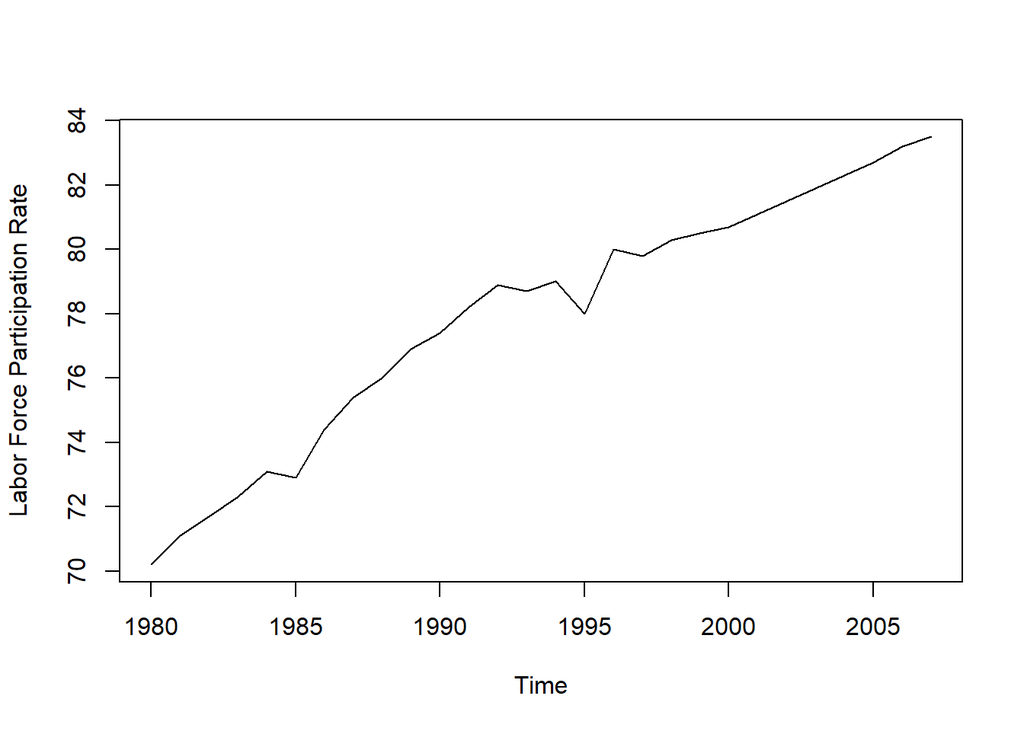

```r
plot(singapur,ylab="Labor Force Participation Rate")
```

From the above chart, the possible models are: - ARIMA - Holt linear trend method

However, one feature of this data is that the values cannnot exceed 100% in the model.There needs to be some press hold. Holt method has a nice damping parameter (holt()).

## Lecture 7: Mission Statement

- How to handle time series with trend?
- Which methods are available?
- What are the pitfalls?
- How to visualize time series data?

The process is 1. Get the dataset 2. Get the mission statement 3. Work on the project 4. Proceed with lectures and check the work

The potential models are: - Linear trend model with `holt()` - With damping paramter - Without damping parameter - ARIMA model

These models can be applied for forecasts, but with pitfalls, visualizations, alternatives.

For applying the above models, we just need: (1) Libraries “forecast” and “ggplo2” + R base functions (2) Resources from the introductory section

## Lecture 9: Exponential smoothing

Forecast package - Simple exponential smooothing: `ses()` - Holt’s linear trend model]: `holt()` +damped - Holt-Winters seasonal method: `hw()` - Automated exponential smooothing: `ets()`

Holt linear trend model is
$$Y_{t+h|t} = l_t + hb_t$$
$Y_{t+h|t}$: estimated forecast value at $t$ time point $l$: level value at $t$ time point $hb_t$: trend value at $t$ time point multiplied by $h$

Should the model react only to recent data or should it consider older data as well? -> Smoothing parameters

Smoothing parameters of a Holt Linear Trend Model are: 1. $\alpha$:smoothing parameter for the level 2. $\beta$:smoothing parameter for the trend

The closer the smoothing parameter is to zero, the model becomes smoooth model (older date is consdered too), otherwise (close to 1) the model is the reactive model, heavily relying on recent data.